# Study 1

Investigating the influence of the agent’s Job Role on the Side-Effect Effect

Bradley Kennedy

21/04/2020

# Study Information

This preregistered study was a lab-based study that investigated how intention is viewed. That is, whether or not an action was planned. Additionally, it investigated how much particular actions deserve praise or blame.

In the study, vignettes were presented to participants. These vignettes varied with high- and low-ranking job roles of the main character. Additionally, the side-effect was varied between helpful and harmful. For example vignettes, see the OSF repository.

The study was conducted through [SuperLab 5](https://cedrus.com/superlab/index.htm) so that the question lists could be randomised for each participant. Participants read 32 vignettes and responded to two questions per vignette. First, they rated to what extent they believed an action was intentional, secondly they rated the amount of praise or blame deserved for the action. Both of these were rated using a 7-point Likert scale from 0 (Not at all) to 6 (Very much). The participants responded on a [Cedrus RB-740 keypad](https://cedrus.com/rb_series/).

Preregistration, materials, analysis code and a copy of the anonymised data will be made publically available on the Open Science Framework, links below.

OSF Repository: https://osf.io/kncea/  
OSF Preregistration: https://osf.io/zat74

# R Set-up

Current R Version: 4.1.0

Check if required packages need to be installed, if so, install

```r
list_of_packages<-c("tidyr","reader","readr","dplyr","psych","ggplot2","Hmisc","ordinal","emmeans","plyr","tidyverse","here")
new.packages <-
  list_of_packages[!(list_of_packages %in% installed.packages()[,"Package"])]
if(length(new.packages))install.packages(new.packages)

lapply(list_of_packages, library, character.only = TRUE)
```

Check for package updates from cloud.r-project.org

```r
update.packages(ask=FALSE, repos = "https://cloud.r-project.org")
```

Import Data & Set variables

```r
all <- read_csv(here("Wrangling","Cleaned_data.csv"))

# Plot data set-up
PlotData <- all
PlotData$Condition <- PlotData$Condition %>%
  as.factor() %>%
  revalue(c("HE"="Helpful", "HA"="Harmful"))
PlotData$Job_ranking <- PlotData$Job_ranking %>%
  as.factor() %>%
  revalue(c("low"="Low rank", "high"="High rank"))

all$ID <- as.factor(all$ID)
all$Age <- as.numeric(all$Age)
all$Sex <- tolower(all$Sex)
all$Sex <- as.factor(all$Sex)
all$StaffStudent <- as.factor(all$StaffStudent)
all$Condition <- as.factor(all$Condition)
all$Intention_rating <- as.ordered(all$Intention_rating)
all$PB_rating <- as.ordered(all$PB_rating)
all$Job_ranking <- as.factor(all$Job_ranking)
all$Item <- as.factor(all$Item)
```

# Participant Descriptives

The mean age of all participants is 24.07 and the standard deviation 8.55.

# Analysis

## Cumulative Link Mixed Models

Christensen, R. H. B. (2019). ordinal - Regression Models for Ordinal Data. R package version 2019.12-10. https://CRAN.R-project.org/package=ordinal.

This centres the fixed factors using deviation coding

```r
contrasts(all$Condition) <- matrix(c(.5, -.5))
contrasts(all$Job_ranking) <- matrix(c(.5, -.5))
```

### Praise Blame Model

DV is `PB_rating` which is the Likert scale response of assigning degree of Praise or Blame (0 to 6) `Job_ranking` is the Agent’s Job ranking experimental factor (levels low & high) `Condition` is the Side Effect Valence experimental factor (level HE = helpful; level HA = harmful)

```r
PB_model <- clmm(PB_rating ~ Condition * Job_ranking + (1 + Condition * Job_ranking|ID) +
                   (1 + Condition * Job_ranking|Item), data = all)
summary(PB_model)
```

```
## Cumulative Link Mixed Model fitted with the Laplace approximation
##
## formula: PB_rating ~ Condition * Job_ranking + (1 + Condition * Job_ranking |
##     ID) + (1 + Condition * Job_ranking | Item)
## data:    all
##
##  link  threshold nobs logLik   AIC      niter       max.grad cond.H
##  logit flexible  3200 -5161.29 10380.57 5938(48701) 1.96e-03 1.7e+02
##
## Random effects:
##  Groups Name                       Variance Std.Dev. Corr
##  ID     (Intercept)                1.858485 1.36326
##         ConditionHE                3.501990 1.87136  -0.608
##         Job_rankinglow             0.002868 0.05356   0.614 -1.000
##         ConditionHE:Job_rankinglow 0.058230 0.24131  -0.126  0.864 -0.860
##  Item   (Intercept)                1.063498 1.03126
##         ConditionHE                2.236750 1.49558  -0.884
##         Job_rankinglow             0.176368 0.41996  -0.786  0.984
##         ConditionHE:Job_rankinglow 0.391339 0.62557   0.820 -0.992 -0.998
## Number of groups:  ID 100,  Item 32
##
## Coefficients:
##                          Estimate Std. Error z value Pr(>|z|)
## Condition1               2.183318   0.297759   7.333 2.26e-13 ***
## Job_ranking1            -0.003953   0.068249  -0.058    0.954
## Condition1:Job_ranking1 -0.038562   0.172339  -0.224    0.823
## ---
## Signif. codes:  0 '***' 0.001 '**' 0.01 '*' 0.05 '.' 0.1 ' ' 1
##
## Threshold coefficients:
##     Estimate Std. Error z value
## 0|1 -3.96561    0.17278 -22.951
## 1|2 -2.51612    0.15851 -15.873
## 2|3 -1.28992    0.15310  -8.425
## 3|4 -0.06031    0.15135  -0.399
## 4|5  1.33316    0.15286   8.721
## 5|6  2.92518    0.16033  18.244
```

This produces the pairwise comparisons for the Praise Blame Model for the interaction of the Agent’s Job ranking (`Job_ranking`) and Side Effect Valence (`Condition`)

```r
emmeans(PB_model, pairwise ~ Job_ranking * Condition, adjust = "none")
```

```
## $emmeans
##  Job_ranking Condition emmean    SE  df asymp.LCL asymp.UCL
##  high        HA         1.676 0.239 Inf     1.207    2.1441
##  low         HA         1.699 0.206 Inf     1.296    2.1017
##  high        HE        -0.488 0.211 Inf    -0.903   -0.0741
##  low         HE        -0.504 0.211 Inf    -0.918   -0.0894
##
## Confidence level used: 0.95
##
## $contrasts
##  contrast          estimate     SE  df z.ratio p.value
##  high,HA - low,HA   -0.0232 0.1197 Inf -0.194  0.8461
##  high,HA - high,HE   2.1640 0.3388 Inf  6.387  <.0001
##  high,HA - low,HE    2.1794 0.3208 Inf  6.793  <.0001
##  low,HA - high,HE    2.1873 0.2893 Inf  7.560  <.0001
##  low,HA - low,HE     2.2026 0.2781 Inf  7.919  <.0001
##  high,HE - low,HE    0.0153 0.0992 Inf  0.155  0.8771
```

This produces the confidence intervals for the main effects and the interction for the Praise Blame Model

```r
confint(PB_model)
```

```
##                              2.5 %     97.5 %
## 0|1                     -4.3042572 -3.6269620
## 1|2                     -2.8268025 -2.2054378
## 2|3                     -1.5899941 -0.9898541
## 3|4                     -0.3569518  0.2363256
## 4|5                      1.0335528  1.6327610
## 5|6                      2.6109326  3.2394340
## Condition1               1.5997211  2.7669146
## Job_ranking1            -0.1377189  0.1298138
## Condition1:Job_ranking1 -0.3763402  0.2992154
```

### Intentionality Model

DV is `Intention_rating` which is the Likert scale response of assigning degree of Intentionality (0 to 6) `Job_ranking` is the Agent’s Job ranking experimental factor (levels low & high) `Condition` is the Side Effect Valence experimental factor (level HE = helpful; level HA = harmful)

```r
Int_model <- clmm(Intention_rating ~ Condition * Job_ranking + (1 + Condition * Job_ranking|ID) +
                    (1 + Condition * Job_ranking|Item), data = all)
summary(Int_model)
```

```
## Cumulative Link Mixed Model fitted with the Laplace approximation
##
## formula: Intention_rating ~ Condition * Job_ranking + (1 + Condition *
##     Job_ranking | ID) + (1 + Condition * Job_ranking | Item)
## data:    all
##
##  link  threshold nobs logLik   AIC      niter       max.grad cond.H
##  logit flexible  3200 -5032.28 10122.56 5654(40100) 2.66e-03 2.0e+02
##
## Random effects:
##  Groups Name                       Variance Std.Dev. Corr
##  ID     (Intercept)                3.013660 1.73599
##         ConditionHE                4.545826 2.13209  -0.616
##         Job_rankinglow             0.008813 0.09388   0.954 -0.824
##         ConditionHE:Job_rankinglow 0.021802 0.14765  -0.361  0.957 -0.624
##  Item   (Intercept)                0.510227 0.71430
##         ConditionHE                1.738972 1.31870  -0.788
##         Job_rankinglow             0.053172 0.23059  -0.730  0.996
##         ConditionHE:Job_rankinglow 0.274402 0.52383   0.841 -0.996 -0.984
## Number of groups:  ID 100,  Item 32
##
## Coefficients:
##                         Estimate Std. Error z value Pr(>|z|)
## Condition1               2.32903    0.29912   7.786 6.89e-15 ***
## Job_ranking1            -0.02493    0.06674  -0.373    0.709
## Condition1:Job_ranking1 -0.11596    0.16131  -0.719    0.472
## ---
## Signif. codes:  0 '***' 0.001 '**' 0.01 '*' 0.05 '.' 0.1 ' ' 1
##
## Threshold coefficients:
##     Estimate Std. Error z value
## 0|1  -3.6786     0.1854 -19.844
## 1|2  -1.7984     0.1730 -10.397
## 2|3  -0.1886     0.1701  -1.109
## 3|4   1.0190     0.1709   5.964
## 4|5   2.3244     0.1749  13.291
## 5|6   3.9767     0.1876  21.200
```

This produces the pairwise comparisons for the Intentionality Model for the interaction of Job ranking (Job_ranking) and Side Effect Valence (Condition)

```r
emmeans(Int_model, pairwise ~ Job_ranking * Condition, adjust = "none")
```

```
## $emmeans
##  Job_ranking Condition emmean    SE  df asymp.LCL asymp.UCL
##  high        HA         0.847 0.225 Inf     0.407     1.288
##  low         HA         0.930 0.219 Inf     0.501     1.360
##  high        HE        -1.424 0.243 Inf    -1.900    -0.948
##  low         HE        -1.457 0.233 Inf    -1.913    -1.001
##
## Confidence level used: 0.95
##
## $contrasts
##  contrast          estimate    SE  df z.ratio p.value
##  high,HA - low,HA   -0.0829 0.100 Inf -0.826  0.4090
##  high,HA - high,HE   2.2711 0.332 Inf  6.850  <.0001
##  high,HA - low,HE    2.3041 0.303 Inf  7.612  <.0001
##  low,HA - high,HE    2.3540 0.310 Inf  7.588  <.0001
##  low,HA - low,HE     2.3870 0.286 Inf  8.335  <.0001
##  high,HE - low,HE    0.0331 0.109 Inf  0.304  0.7613
```

```r
confint(Int_model)
```

```
##                              2.5 %     97.5 %
## 0|1                     -4.0419074 -3.3152639
## 1|2                     -2.1374384 -1.4594039
## 2|3                     -0.5219582  0.1447118
## 3|4                      0.6841086  1.3538327
## 4|5                      1.9816730  2.6672162
## 5|6                      3.6090479  4.3443529
## Condition1               1.7427777  2.9152906
## Job_ranking1            -0.1557421  0.1058855
## Condition1:Job_ranking1 -0.4321237  0.2002002
```

### Null models

```r
PB_null <- clmm(PB_rating ~ 1 + (1 + Job_ranking * Condition | ID) +
                  (1 + Job_ranking * Condition | Item),
                data = all)
Int_null <- clmm(PB_rating ~ 1 + (1 + Job_ranking * Condition | ID) +
                   (1 + Job_ranking * Condition | Item),
                 data = all)
# Comparisons with null models
anova(PB_null, PB_model)
```

```
## Likelihood ratio tests of cumulative link models:
##
##          formula:
## PB_null  PB_rating ~ 1 + (1 + Job_ranking * Condition | ID) + (1 + Job_ranking * Condition | Item)
## PB_model PB_rating ~ Condition * Job_ranking + (1 + Condition * Job_ranking | ID) + (1 + Condition * Job_ranking | Item)
##          link: threshold:
## PB_null  logit flexible
## PB_model logit flexible
##
##          no.par   AIC  logLik LR.stat df Pr(>Chisq)
## PB_null      26 10422 -5184.8
## PB_model     29 10381 -5161.3  47.105  3  3.301e-10 ***
## ---
## Signif. codes:  0 '***' 0.001 '**' 0.01 '*' 0.05 '.' 0.1 ' ' 1
```

```r
anova(Int_null, Int_model)
```

```
## Likelihood ratio tests of cumulative link models:
##
##           formula:
## Int_null  PB_rating ~ 1 + (1 + Job_ranking * Condition | ID) + (1 + Job_ranking * Condition | Item)
## Int_model Intention_rating ~ Condition * Job_ranking + (1 + Condition * Job_ranking | ID) + (1 + Condition * Job_ranking | Item)
##           link: threshold:
## Int_null  logit flexible
## Int_model logit flexible
##
##           no.par   AIC  logLik LR.stat df Pr(>Chisq)
## Int_null      26 10422 -5184.8
## Int_model     29 10123 -5032.3  305.12  3  < 2.2e-16 ***
## ---
## Signif. codes:  0 '***' 0.001 '**' 0.01 '*' 0.05 '.' 0.1 ' ' 1
```

### Main Effects Models

```r
PB_model_main <- clmm(PB_rating ~ Job_ranking + Condition +
                        (1 + Job_ranking + Condition | ID) +
                   (1 + Job_ranking + Condition | Item), data = all)
summary(PB_model_main)
```

```
## Cumulative Link Mixed Model fitted with the Laplace approximation
##
## formula: PB_rating ~ Job_ranking + Condition + (1 + Job_ranking + Condition |
##     ID) + (1 + Job_ranking + Condition | Item)
## data:    all
##
##  link  threshold nobs logLik   AIC      niter       max.grad cond.H
##  logit flexible  3200 -5171.53 10383.07 3728(29315) 3.03e-03 2.4e+04
##
## Random effects:
##  Groups Name           Variance Std.Dev. Corr
##  ID     (Intercept)    1.878205 1.37048
##         Job_rankinglow 0.007515 0.08669  -0.101
##         ConditionHE    3.918811 1.97960  -0.626  0.839
##  Item   (Intercept)    0.816183 0.90343
##         Job_rankinglow 0.004210 0.06489  -0.590
##         ConditionHE    1.463589 1.20979  -0.848  0.928
## Number of groups:  ID 100,  Item 32
##
## Coefficients:
##              Estimate Std. Error z value Pr(>|z|)
## Job_ranking1  0.00456    0.06633   0.069    0.945
## Condition1    2.17790    0.29944   7.273 3.51e-13 ***
## ---
## Signif. codes:  0 '***' 0.001 '**' 0.01 '*' 0.05 '.' 0.1 ' ' 1
##
## Threshold coefficients:
##     Estimate Std. Error z value
## 0|1 -3.95007    0.17046 -23.173
## 1|2 -2.50811    0.15609 -16.068
## 2|3 -1.28795    0.15069  -8.547
## 3|4 -0.06346    0.14904  -0.426
## 4|5  1.32313    0.15069   8.781
## 5|6  2.90924    0.15836  18.371
```

```r
anova(PB_model_main, PB_model)
```

```
## Likelihood ratio tests of cumulative link models:
##
##               formula:
## PB_model_main PB_rating ~ Job_ranking + Condition + (1 + Job_ranking + Condition | ID) + (1 + Job_ranking + Condition | Item)
## PB_model      PB_rating ~ Condition * Job_ranking + (1 + Condition * Job_ranking | ID) + (1 + Condition * Job_ranking | Item)
##               link: threshold:
## PB_model_main logit flexible
## PB_model      logit flexible
##
##               no.par   AIC  logLik LR.stat df Pr(>Chisq)
## PB_model_main     20 10383 -5171.5
## PB_model          29 10381 -5161.3  20.492  9    0.01511 *
## ---
## Signif. codes:  0 '***' 0.001 '**' 0.01 '*' 0.05 '.' 0.1 ' ' 1
```

```r
Int_model_main_reduced <- clmm(Intention_rating ~ Job_ranking + Condition +
                         (1 + Job_ranking + Condition | ID), data = all)
Int_tocompare <- clmm(Intention_rating ~ Condition * Job_ranking +
                        (1 + Condition * Job_ranking|ID), data = all)
summary(Int_model_main_reduced)
```

```
## Cumulative Link Mixed Model fitted with the Laplace approximation
##
## formula: Intention_rating ~ Job_ranking + Condition + (1 + Job_ranking +
##     Condition | ID)
## data:    all
##
##  link  threshold nobs logLik   AIC      niter       max.grad cond.H
##  logit flexible  3200 -5162.36 10352.72 1829(12672) 3.57e-04 1.5e+02
##
## Random effects:
##  Groups Name           Variance Std.Dev. Corr
##  ID     (Intercept)    2.73258  1.6531
##         Job_rankinglow 0.01136  0.1066    0.465
##         ConditionHE    4.45357  2.1103   -0.648  0.374
## Number of groups:  ID 100
##
## Coefficients:
##              Estimate Std. Error z value Pr(>|z|)
## Job_ranking1 -0.02504    0.06551  -0.382    0.702
## Condition1    2.22338    0.22410   9.921   <2e-16 ***
## ---
## Signif. codes:  0 '***' 0.001 '**' 0.01 '*' 0.05 '.' 0.1 ' ' 1
##
## Threshold coefficients:
##     Estimate Std. Error z value
## 0|1  -3.4226     0.1551 -22.061
## 1|2  -1.6491     0.1417 -11.641
## 2|3  -0.1488     0.1387  -1.073
## 3|4   0.9589     0.1395   6.874
## 4|5   2.1602     0.1437  15.035
## 5|6   3.7167     0.1575  23.598
```

```r
anova(Int_model_main_reduced, Int_tocompare)
```

```
## Likelihood ratio tests of cumulative link models:
##
##                        formula:
## Int_model_main_reduced Intention_rating ~ Job_ranking + Condition + (1 + Job_ranking + Condition | ID)
## Int_tocompare          Intention_rating ~ Condition * Job_ranking + (1 + Condition * Job_ranking | ID)
##                        link: threshold:
## Int_model_main_reduced logit flexible
## Int_tocompare          logit flexible
##
##                        no.par   AIC  logLik LR.stat df Pr(>Chisq)
## Int_model_main_reduced     14 10353 -5162.4
## Int_tocompare              19 10362 -5161.8   1.081  5     0.9558
```

# Raincloud Plot

### Praise Blame Raincloud

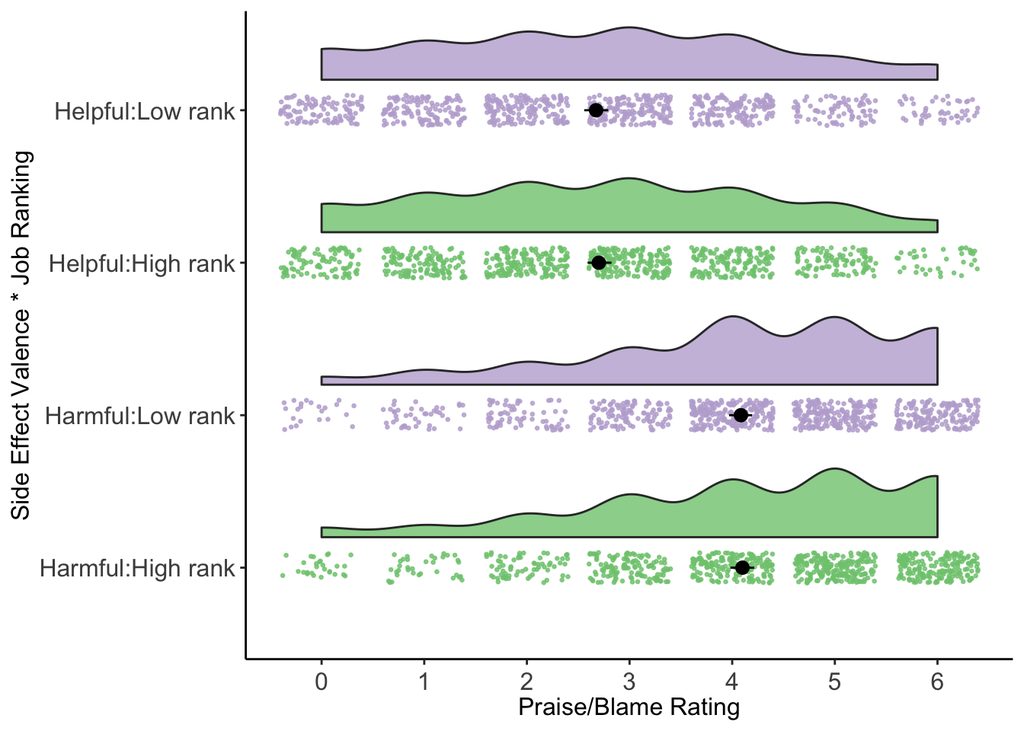

```r
source("https://gist.githubusercontent.com/benmarwick/2a1bb0133ff568cbe28d/raw/fb53bd97121f7f9ce947837ef1a4c65a73bffb3f/geom_flat_violin.R")
raincloud_theme = theme(text = element_text(size = 12),
                        axis.title.x = element_text(size = 12),
                        axis.title.y = element_text(size = 12),
                        axis.text = element_text(size = 12),
                        axis.text.x = element_text(vjust = 0.5),
                        legend.title=element_text(size=12),
                        legend.text=element_text(size=12),
                        legend.position = "right",
                        plot.title = element_text(lineheight=.8, face="bold", size = 16),
                        panel.border = element_blank(),
                        panel.grid.minor = element_blank(),
                        panel.grid.major = element_blank(),
                        axis.line.x = element_line(colour = 'black', size=0.5, linetype='solid'),
                        axis.line.y = element_line(colour = 'black', size=0.5, linetype='solid'))

PB_Rain <- ggplot(data = PlotData,
                 aes(y = PB_rating, x = Condition:Job_ranking, fill = Job_ranking)) +
  geom_flat_violin(position = position_nudge(x = .2, y = 0), alpha = .8, trim=TRUE) +
  geom_point(aes(y = PB_rating, color = Job_ranking),
             position = position_jitter(width = .10), size = .5, alpha = 0.8) +
  expand_limits(x = 3) +
  guides(fill = FALSE) +
  guides(color = FALSE) +
  scale_color_brewer(palette = "Accent") +
  scale_fill_brewer(palette = "Accent") +
  coord_flip() + theme_bw() +
  raincloud_theme +
  labs(x="Side Effect Valence * Job Ranking") +
  scale_y_continuous(breaks = seq(0,6,by = 1)) + ylab("Praise/Blame Rating") +
  stat_summary(fun.data="mean_cl_boot", colour="black", size=.5)
PB_Rain
```

### Intention Raincloud

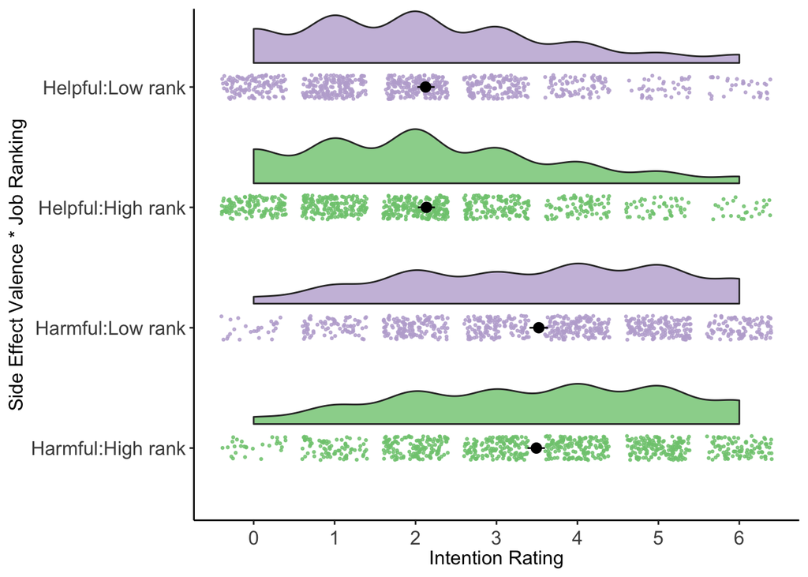

```r
Int_Rain <- ggplot(data = PlotData,
                 aes(y = Intention_rating, x = Condition:Job_ranking, fill = Job_ranking)) +
  geom_flat_violin(position = position_nudge(x = .2, y = 0), alpha = .8, trim=TRUE) +
  geom_point(aes(y = Intention_rating, color = Job_ranking),
             position = position_jitter(width = .10), size = .5, alpha = 0.8) +
  expand_limits(x = 3) +
  guides(fill = FALSE) +
  guides(color = FALSE) +
  scale_color_brewer(palette = "Accent") +
  scale_fill_brewer(palette = "Accent") +
  coord_flip() + theme_bw() +
  raincloud_theme +
  labs(x="Side Effect Valence * Job Ranking") +
  scale_y_continuous(breaks = seq(0,6,by = 1)) + ylab("Intention Rating") +
  stat_summary(fun.data="mean_cl_boot", colour="black", size=.5)
Int_Rain
```

# Research Team

This research was conducted by [Bradley Kennedy](https://bradk.co.uk)  
Principal Supervisor: Dr Suzanne L. K. Stewart  
Supervision Team: Dr Annie Scudds & Professor Moira Lafferty

[figure not shown]